# Variáveis Aleatórias Multidimensionais

Associação entre Variáveis Aleatórias

Alexandre Nicolella

nicolella@usp.br

FEARP/USP

2026-03-17

# Covariância e Coeficiente de Correlação

# Coeficiente de Correlação

## Definindo 📖

- Até o momento medimos a $E(X)$ e a $Var(X)$, ou seja, uma medida de posição e de variabilidade em relação a $R_x$,
- Quando temos um vetor bidimensional $(X,Y)$ uma outra medida surge, o “grau de associação” linear entre $X$ e $Y$.

**DEFINIÇÃO**

Seja $(X,Y)$ uma variável aleatória bidimensional. O **Coeficiente de Correlação** $\rho_{X,Y}$ entre $X$ e $Y$ será:

$$\begin{array}{ccc}
\rho_{X,Y}=\frac{E[(X-E(X))(Y-E(Y))]}{\sqrt{Var(X)Var(Y)}}
\end{array}$$

# A Covariância

## Definindo 📖

- Um termo muito importante surge na expressão acima, a **Covariância**.
- Ela mede a variabilidade conjunta de uma variável aleátoria multidimensional.

**DEFINIÇÃO**

A **Covariância** entre $X$ e $Y$, $Cov(X,Y)$, é dada por:
$$\begin{array}{ccc}
Cov(X,Y)=E[(X-E(X))(Y-E(Y))]
\end{array}$$

- Para tirar o efeito das escalas de medidas, dividimos pelos desvio-padrões.

# Propriedades do Coef. de Correlação

## Definindo 📖

- Novamente, a correlação mede o **GRAU DE ASSOCIAÇÃO LINEAR**.
- Vejamos algumas Propriedades da Correlação:

**TEOREMA**

O coeficiente de correlação $\rho_{X,Y}$ entre $X$ e $Y$ pode ser apresentado como:
$$\begin{array}{ccc}
\rho_{X,Y}=\frac{E(XY)-E(X)E(Y)}{\sqrt{Var(X)Var(Y)}}
\end{array}$$

## Definindo 📖

**TEOREMA**

**Prova:**
$$\begin{array}{ccc}
E[(X-E(X))(Y-E(Y))]\\
\\
=E[XY-XE(Y)-E(X)Y+E(X)E(Y)] \\
\\
= E(XY)-E(X)E(Y)-E(X)E(Y)+E(X)E(Y)\\
\\
= E(XY)-E(X)E(Y)
\end{array}$$

## Independência e a Correlação

**TEOREMA**

Se $X$ e $Y$ forem independentes então:
$$\begin{array}{ccc}
\rho_{X,Y}=0
\end{array}$$

**Prova:**

Da propriedade da independência, se $X$ e $Y$ forem independentes então:
$$\begin{array}{ccc}
E(X,Y)=E(X)E(Y)
\end{array}$$

Considerando o teorema acima, e sabendo que as variáveis são independentes, então $\rho_{X,Y}=0$

## Importante:

- Note que Independência $\Rightarrow \rho_{X,Y}=0$
- Mas **não** é verdade que $\rho_{X,Y}=0 \Rightarrow Independência$

## O Intervalo da Correlação

**TEOREMA**

O Coeficiente de Correlação possui valores entre -1 e 1, ou seja:
$$\begin{array}{ccc}
-1 \leq \rho \leq 1
\end{array}$$

**Prova:**

Considere a seguinte desigualdade verdadeira:
$$\begin{array}{ccc}
(\frac{x-\mu_x}{\sigma_x}\mp \frac{Y-\mu_y}{\sigma_y} )^{2}\geq 0
\end{array}$$

A expressão continua verdadeira se aplicarmos o operador esperança:

$$\begin{array}{ccc}
E(\frac{x-\mu_x}{\sigma_x}\mp \frac{Y-\mu_y}{\sigma_y} )^{2}\geq 0
\end{array}$$

## O Intervalo da Correlação

**TEOREMA**

**Continuação Prova:**

Desenvolvendo, temos que:
$$\begin{array}{ccc}
E[(\frac{x-\mu_x}{\sigma_x})^{2}+(\frac{Y-\mu_y}{\sigma_y})^{2} \mp 2 (\frac{x-\mu_x}{\sigma_x})(\frac{Y-\mu_y}{\sigma_y}) ]\geq 0
\end{array}$$

$$\begin{array}{ccc}
\frac{1}{\sigma_x^{2}}E({X-\mu_x})^{2}+\frac{1}{\sigma_y^{2}}E({Y-\mu_y})^{2}\mp 2 \frac{1}{\sigma_x \sigma_y}E((X-\mu_x)(Y-\mu_y) )\geq 0
\end{array}$$

$$\begin{array}{ccc}
\frac{\sigma_x^{2}}{\sigma_x^{2}}+\frac{\sigma_y^{2}}{\sigma_y^{2}}\mp 2\rho \geq 0
\end{array}$$

$$\begin{array}{ccc}
\mp 2\rho \geq -2
\end{array}$$

$$\begin{array}{ccc}
\therefore \rho \geq -1 \ e \ \rho \leq 1
\end{array}$$

## Correlação: Associação linear

**TEOREMA**

Se X e Y forem duas variáveis aleatórias, onde $Y=AX+B$, onde A e B são constantes. Então $\rho^{2}=1$. Se $A>0$, $\rho=1$. Se $A<0$, $\rho=-1$

**Prova:**

$$\begin{array}{ccc}
Y= AX +B
\\
E(Y)=A E(X)+ B \ e \ VAR(Y)=A^{2}VAR(X)
\\
E(XY)=E(AX^{2}+BX) \ \rightarrow AE(X^{2})+BE(X)
\end{array}$$

Então:
$$\begin{array}{ccc}
\rho^{2}=\frac{A^{2}{Var(X)}}{A^{2}{Var(X)}}=1
\end{array}$$

## O Coeficiente de Correlação

- Assim, com base no exposto, temos que o coeficiente de correlação é uma medida do grau de linearidade entre X e Y.
- Dessa forma, $\rho$ próximo a 1 e -1 indicam alto grau de linearidade e $\rho$ próximo a zero indica ausência de relação linear - mas não diz nada sobre relações não-lineares.

# Correlação: Graficamente

## Simulando as Variáveis e Visualizando

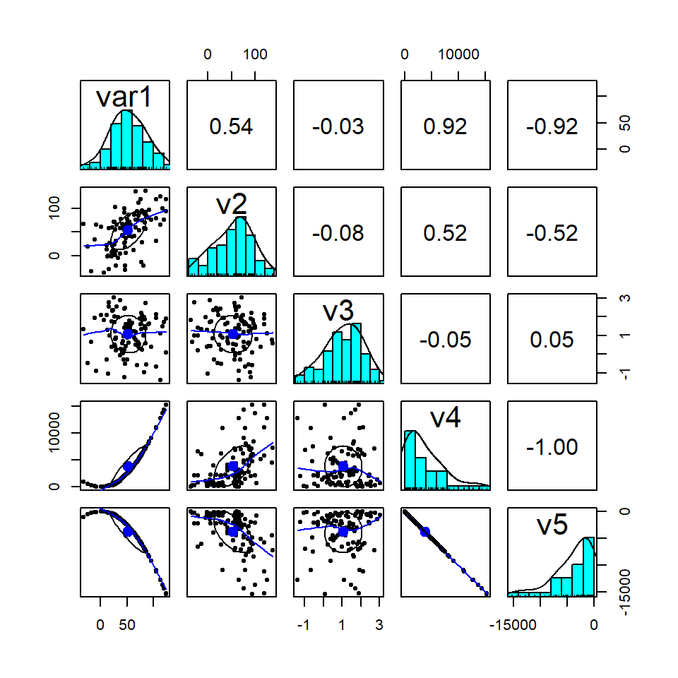

Gráfico de correlação para variáveis simuladas v1 a v5

## Correlação: Visualização gráfica

- Perceba que a relação não-linear entre v1 e v4 e v1 e v5, faz com que a correlação seja menor que 1 e não perfeita.
- Já as variáveis v1 e v2 mostram comportamento conjunto positivo, mas não perfeito, reativamente disperso. Quando v1 sobe, v2 também sobe, entretanto não cosneguimos prever esse comportamento perfeitamente.